# modelagem_final

Murilo Cechin, Marcello Caron, Mariana Aukar

2023-09-12

# Modelagem Projeto Integrador

Arquivo de modelagem da atividade integradora.

O grupo selecionou os seguintes algoritimos para realizar a modelagem de classificação:

- Random Forest
- Regressão Logistica
- Ridge
- XGboost

## Importando arquivo

```r
df_final = read.csv('df_final.csv')

head(df_final, 10)
```

```
##      X comp_id amort_log curr_assets_log curr_liab_log extra_exp_log
## 1   23 1002029  9.611103       12.225312     11.698944      0.000000
## 2   56 1011889 10.508512       11.983970      9.847505      0.000000
## 3   68 1014183  9.437623       12.205591      9.020882      0.000000
## 4   80 1018301  0.000000        7.501696      6.384507      0.000000
## 5   91 1022796  6.535080        8.726914      8.823588      0.000000
## 6  102 1035705  5.528841        8.118373      8.025928      0.000000
## 7  113 1046213 11.111618       14.693673     14.018859      9.897358
## 8  124 1056952  5.831122        7.391552     10.089813      0.000000
## 9  135 1070690  0.000000        9.047821      7.138279      0.000000
## 10 170 1109346  4.710531        9.699829      7.225535      0.000000
##    extra_inc_log extra_profit_loss_log fixed_assets_log inc_bef_tax_log
## 1       0.000000              0.000000        10.063021        9.377423
## 2       0.000000              0.000000        13.746776       11.479905
## 3       2.002480              2.002480        11.680384       -7.265171
```

[output cut: 62 more lines]

Antes de prosseguir com a modelagem é necessario retirar algumas colunas deste dataframe. Como a coluna X, que representa o index do pré-processamento em python e a coluna comp_id que apenas fornece o código da empresa.

```r
df_final$X <- NULL
```

```r
df_final$comp_id <- NULL
```

```r
head(df_final, 10)
```

```
##    amort_log curr_assets_log curr_liab_log extra_exp_log extra_inc_log
## 1   9.611103       12.225312     11.698944      0.000000      0.000000
## 2  10.508512       11.983970      9.847505      0.000000      0.000000
## 3   9.437623       12.205591      9.020882      0.000000      2.002480
## 4   0.000000        7.501696      6.384507      0.000000      2.407946
## 5   6.535080        8.726914      8.823588      0.000000      0.000000
## 6   5.528841        8.118373      8.025928      0.000000      0.000000
## 7  11.111618       14.693673     14.018859      9.897358      0.000000
## 8   5.831122        7.391552     10.089813      0.000000      0.000000
## 9   0.000000        9.047821      7.138279      0.000000      0.000000
## 10  4.710531        9.699829      7.225535      0.000000      0.000000
##    extra_profit_loss_log fixed_assets_log inc_bef_tax_log intang_assets_log
## 1               0.000000        10.063021        9.377423          0.000000
## 2               0.000000        13.746776       11.479905          7.337612
## 3               2.002480        11.680384       -7.265171          0.000000
```

[output cut: 62 more lines]

### Colunas com log

Caso seja necessario realizar a interpretação do código, rodar a função abaixo:

```r
back_log <- function(x) {
  if (x > 0) {
    return(exp(x))
  } else if (x == 0) {
    return(0)
  } else {
    y <- -1 * x
    return(exp(y) * -1)
  }
}
```

Aplicando na coluna profit_loss_year_log para demonstrar:

```r
# Antes de aplicar a função
head(df_final$profit_loss_year_log, 10)
```

```
##  [1]  9.182170 11.479905 -7.762958 -7.009777 -7.178630 -8.987197 11.608438
##  [8] -9.328617  7.600902  6.911452
```

```r
# Aplicando a função
head(sapply(df_final$profit_loss_year_log, back_log), 10)
```

```
##  [1]   9722.223  96751.852  -2351.852  -1107.407  -1311.111  -8000.000
##  [7] 110022.219 -11255.556   2000.000   1003.704
```

### Conjunto de teste e treinamento

Separando os conjuntos de teste e treinamento.

Antes, vamos analisar se o cojunto de dados está desbalanceado.

```r
# Analise das frequencia

df_final %>%
  group_by(target) %>%
  summarise(freq_absoluta = n()) %>%
  mutate(freq_relativa = (freq_absoluta / sum(freq_absoluta))*100)
```

```
## # A tibble: 2 × 3
##   target freq_absoluta freq_relativa
##    <dbl>         <int>         <dbl>
## 1      0         13863          85.6
## 2      1          2326          14.4
```

Percebemos que a base de dados apresenta um desbalanceamento significativo, com somente 14% das empresas sendo classificadas como inativas. Devido a essa disparidade, a métrica de acurácia pode não oferecer uma visão completa do desempenho do modelo. Por isso, optaremos pela Area Under the Curve (AUC) como métrica principal, pois ela faz um balanço entre Sensibilidade e Especificidade.

A AUC é menos sensível a desequilíbrio de classes do que algumas outras métricas, como a acurácia. Em problemas onde as classes estão desequilibradas, a AUC pode oferecer uma avaliação mais confiável do desempenho do modelo.

Para dividir os conjuntos de treinamento e teste, vamos adotar uma amostragem estratificada, de forma a preservar a proporção da variável alvo.

```r
# Configurando semente aleatoria
set.seed(123)

# Aplicando função factor

df_final$target <- factor(df_final$target)

splits <- initial_split(df_final, prop = .8, strata="target")

conj_treinamento <- training(splits)
conj_teste <- testing(splits)
```

Conferindo proporção do conjunto de teste

```r
conj_teste %>%
  group_by(target) %>%
  summarise(freq_absoluta = n()) %>%
  mutate(freq_relativa = (freq_absoluta / sum(freq_absoluta))*100)
```

```
## # A tibble: 2 × 3
##   target freq_absoluta freq_relativa
##   <fct>          <int>         <dbl>
## 1 0               2773          85.6
## 2 1                466          14.4
```

Conferindo conjunto de treinamento

```r
conj_treinamento %>%
  group_by(target) %>%
  summarise(freq_absoluta = n()) %>%
  mutate(freq_relativa = (freq_absoluta / sum(freq_absoluta))*100)
```

```
## # A tibble: 2 × 3
##   target freq_absoluta freq_relativa
##   <fct>          <int>         <dbl>
## 1 0              11090          85.6
## 2 1               1860          14.4
```

Como pode ser obsevado , a estratificação funcionou.

### Criando Tabela de comparação

```r
tb_metricas <- tibble(
  modelo = c("Random Forest","Regressão Logistica", "Ridge", "XGboost"),
  AUC = c(NA, NA, NA, NA),
)

tb_metricas
```

```
## # A tibble: 4 × 2
##   modelo              AUC
##   <chr>               <lgl>
## 1 Random Forest       NA
## 2 Regressão Logistica NA
## 3 Ridge               NA
## 4 XGboost             NA
```

### Random Forest

Criando modelagem com algoritmo random forest.

```r
random <- ranger(target ~ ., data=conj_treinamento, probability = TRUE)

print(random)
```

```
## Ranger result
##
## Call:
##  ranger(target ~ ., data = conj_treinamento, probability = TRUE)
##
## Type:                             Probability estimation
## Number of trees:                  500
## Sample size:                      12950
## Number of independent variables:  32
## Mtry:                             5
## Target node size:                 10
## Variable importance mode:         none
## Splitrule:                        gini
## OOB prediction error (Brier s.):  0.09383175
```

AUC para Random Forest pré-otimização de hiperparâmetros

```r
teste_random = predict(random, conj_teste)

probs_numeric <- as.numeric(as.character(teste_random$predictions[,2]))
labels_numeric <- as.numeric(as.character(conj_teste$target))

roc_obj <- roc(labels_numeric, probs_numeric)
auc_random <- auc(roc_obj)

auc_random
```

```
## Area under the curve: 0.8346
```

Otimizando os hiperparâmetros de n_trees e Mtry.

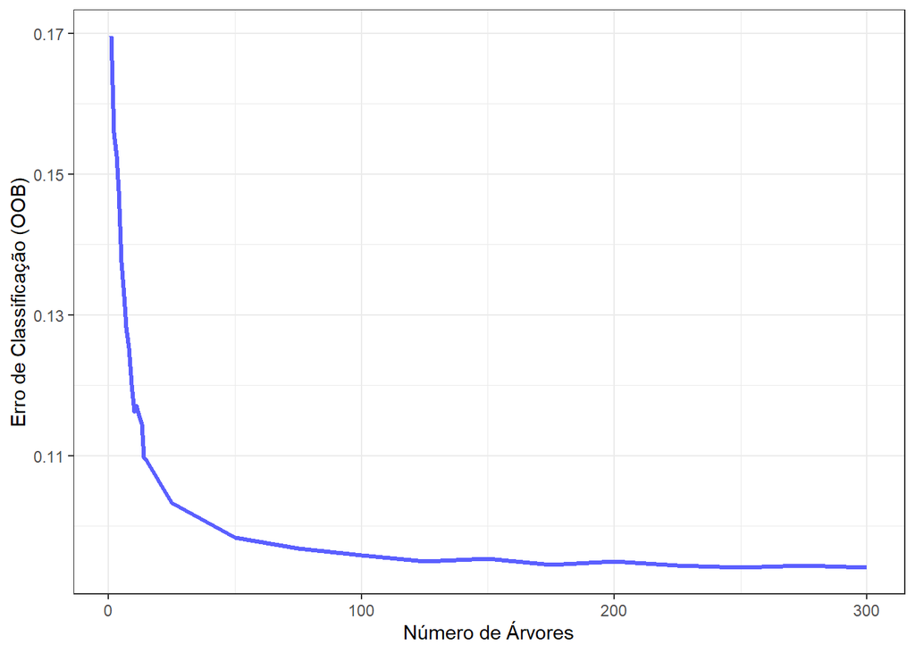

```r
# Buscando um número otimo de n_trees
random_ntree <- tibble(n_arvores = c(1:15, seq(25, 300, 25)), erro = NA)

random_ntree <- random_ntree %>%
  mutate(erro = map_dbl(n_arvores, ~ranger(target ~ ., num.trees = .x, data=conj_treinamento, probability = TRUE)$prediction.error))

random_ntree %>%
  ggplot(aes(n_arvores, erro)) +
    geom_line(color = "#5B5FFF", size = 1.2) +
    labs(x = "Número de Árvores", y = "Erro de Classificação (OOB)") +
    theme_bw()
```

Analisando o gráfico gerado, iremos testar entre 50 e 250 árvores.

```r
# Otimizando o mtry e o número de árvores.
resultados <- crossing(mtry = c(4, 8, 10, 15, 20, 25, 30),
                       n_arvores = c(seq(50, 250, 25)))

ajusta <- function(mtry, n_arvores) {
   set.seed(123)
   random <- ranger(target ~ ., num.trees = n_arvores, mtry = mtry, data = conj_treinamento, probability = TRUE)
   return(random$prediction.error)
}

resultados <- resultados %>%
  mutate(erro = map2_dbl(mtry, n_arvores, ajusta))


head(resultados)
```

```
## # A tibble: 6 × 3
##    mtry n_arvores   erro
##   <dbl>     <dbl>  <dbl>
## 1     4        50 0.0968
## 2     4        75 0.0956
## 3     4       100 0.0951
## 4     4       125 0.0949
## 5     4       150 0.0946
## 6     4       175 0.0943
```

Plotando os resultados

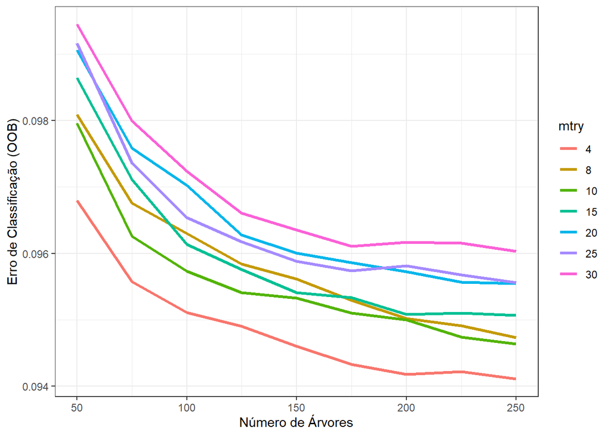

```r
resultados %>%
  mutate(mtry = factor(mtry)) %>%
  ggplot(aes(n_arvores, erro, group = mtry, color = mtry)) +
    geom_line( size = 1.2) +
    labs(x = "Número de Árvores", y = "Erro de Classificação (OOB)") +
    theme_bw()
```

Analisando resultados com os menores erros:

```r
resultados %>%
  arrange(erro)
```

```
## # A tibble: 63 × 3
##     mtry n_arvores   erro
##    <dbl>     <dbl>  <dbl>
##  1     4       250 0.0941
##  2     4       200 0.0942
##  3     4       225 0.0942
##  4     4       175 0.0943
##  5     4       150 0.0946
##  6    10       250 0.0946
##  7     8       250 0.0947
##  8    10       225 0.0947
##  9     4       125 0.0949
## 10     8       225 0.0949
## # ℹ 53 more rows
```

A árvore otimizada será com mtry = 4 e n_arvores = 250.

```r
conj_treinamento$target <- as.factor(conj_treinamento$target)

random_final <- ranger(target ~., data=conj_treinamento, num.trees = 250, mtry=4, probability = TRUE)

print(random_final)
```

```
## Ranger result
##
## Call:
##  ranger(target ~ ., data = conj_treinamento, num.trees = 250,      mtry = 4, probability = TRUE)
##
## Type:                             Probability estimation
## Number of trees:                  250
## Sample size:                      12950
## Number of independent variables:  32
## Mtry:                             4
## Target node size:                 10
## Variable importance mode:         none
## Splitrule:                        gini
## OOB prediction error (Brier s.):  0.09469377
```

Realizando predição no conjunto de teste

```r
# Realizando predições no conjunto de teste
predicoes_random <- predict(random_final, data = conj_teste)

# Probabilidades da classe positiva
probs_random <- factor(ifelse(predicoes_random$predictions[,2] > 0.5, 1, 0))

# Matriz de confusão e sensibilidade
confusion_random <- caret::confusionMatrix(data=probs_random, reference = as.factor(conj_teste$target), positive='1')

confusion_random
```

```
## Confusion Matrix and Statistics
##
##           Reference
## Prediction    0    1
##          0 2702  363
##          1   71  103
##
##                Accuracy : 0.866
##                  95% CI : (0.8538, 0.8776)
##     No Information Rate : 0.8561
##     P-Value [Acc > NIR] : 0.05634
##
##                   Kappa : 0.2643
##
##  Mcnemar's Test P-Value : < 2e-16
##
##             Sensitivity : 0.22103
##             Specificity : 0.97440
##          Pos Pred Value : 0.59195
##          Neg Pred Value : 0.88157
##              Prevalence : 0.14387
##          Detection Rate : 0.03180
##    Detection Prevalence : 0.05372
##       Balanced Accuracy : 0.59771
##
##        'Positive' Class : 1
##
```

Obtendo a AUC:

```r
probs_numeric <- as.numeric(as.character(predicoes_random$predictions[,2]))
labels_numeric <- as.numeric(as.character(conj_teste$target))

roc_obj <- roc(labels_numeric, probs_numeric)
auc_random <- auc(roc_obj)

auc_random
```

```
## Area under the curve: 0.8318
```

Adicionando resultados no tibble de comparação

```r
tb_metricas$AUC[tb_metricas$modelo == "Random Forest"] = auc_random
tb_metricas
```

```
## # A tibble: 4 × 2
##   modelo                 AUC
##   <chr>                <dbl>
## 1 Random Forest        0.832
## 2 Regressão Logistica NA
## 3 Ridge               NA
## 4 XGboost             NA
```

### Regressão Logistica

```r
reg_logistica <- glm(target ~ ., data = conj_treinamento, family = "binomial")

reg_logistica
```

```
##
## Call:  glm(formula = target ~ ., family = "binomial", data = conj_treinamento)
##
## Coefficients:
##           (Intercept)              amort_log        curr_assets_log
##             2.2296050             -0.0525624              0.1088334
##         curr_liab_log          extra_exp_log          extra_inc_log
##             0.1254254             -0.0146053              0.0400723
## extra_profit_loss_log       fixed_assets_log        inc_bef_tax_log
##             0.0023010             -0.0720467             -0.0441437
##     intang_assets_log        inventories_log         liq_assets_log
##            -0.0382643             -0.1063816             -0.1534036
##      material_exp_log      personnel_exp_log   profit_loss_year_log
##            -0.0029486             -0.0354474              0.0133343
##             sales_log           share_eq_log     subscribed_cap_log
##            -0.2140608             -0.0169755             -0.0371528
##       tang_assets_log              ceo_count                foreign
##             0.0035030             -0.2509358             -2.6367879
##                female          inoffice_days             gendermale
##             0.3901126             -0.0004251              0.6051359
##             gendermix          originForeign              originmix
##             0.4303081              2.5966064              1.5801742
##                   ind                urban_m           region_mEast
##             0.1420836             -0.0551145              0.0896384
##          region_mWest          labor_avg_log               comp_age
##            -0.1324000              0.1664839              0.0073719
##               CEO_age          endividamento            debt_equity
##            -0.0049662              0.0003037              0.0004746
##
## Degrees of Freedom: 12949 Total (i.e. Null);  12914 Residual
## Null Deviance:       10660
## Residual Deviance: 8212  AIC: 8284
```

Cálculando as probabilidades

```r
prob_log <- predict(reg_logistica, conj_teste, type = "response")
```

Matriz de confusão

```r
class_log <- ifelse(prob_log > 0.5, 1, 0)

# Matriz de confusão e sensibilidade
confusion_reglog <- caret::confusionMatrix(data=factor(class_log), reference = as.factor(conj_teste$target), positive='1')

confusion_reglog
```

```
## Confusion Matrix and Statistics
##
##           Reference
## Prediction    0    1
##          0 2690  361
##          1   83  105
##
##                Accuracy : 0.8629
##                  95% CI : (0.8506, 0.8746)
##     No Information Rate : 0.8561
##     P-Value [Acc > NIR] : 0.1406
##
##                   Kappa : 0.2599
##
##  Mcnemar's Test P-Value : <2e-16
##
##             Sensitivity : 0.22532
##             Specificity : 0.97007
##          Pos Pred Value : 0.55851
##          Neg Pred Value : 0.88168
##              Prevalence : 0.14387
##          Detection Rate : 0.03242
##    Detection Prevalence : 0.05804
##       Balanced Accuracy : 0.59770
##
##        'Positive' Class : 1
##
```

Cálculando métrica AUC

```r
roc_log <- roc(conj_teste$target, prob_log)
roc_log
```

```
##
## Call:
## roc.default(response = conj_teste$target, predictor = prob_log)
##
## Data: prob_log in 2773 controls (conj_teste$target 0) < 466 cases (conj_teste$target 1).
## Area under the curve: 0.8135
```

Adicionando AUC para a tabela de resultados

```r
tb_metricas$AUC[tb_metricas$modelo == "Regressão Logistica"] = roc_log$auc

tb_metricas
```

```
## # A tibble: 4 × 2
##   modelo                 AUC
##   <chr>                <dbl>
## 1 Random Forest        0.832
## 2 Regressão Logistica  0.814
## 3 Ridge               NA
## 4 XGboost             NA
```

### Ridge

Para utilizar o pacote glmnet, primeiro é necessario realizar um tratamento nos conjuntos de teste e treinamento.

```r
conj_treinamento_matrix <- model.matrix(target~., data = conj_treinamento)[, -1]

conj_teste_matrix <- model.matrix(target~. , data = conj_teste)[, -1]
```

Treinando o modelo

```r
ridge <- glmnet(conj_treinamento_matrix, conj_treinamento$target, alpha = 0, family = "binomial")

summary(ridge)
```

```
##            Length Class     Mode
## a0          100   -none-    numeric
## beta       3500   dgCMatrix S4
## df          100   -none-    numeric
## dim           2   -none-    numeric
## lambda      100   -none-    numeric
## dev.ratio   100   -none-    numeric
## nulldev       1   -none-    numeric
## npasses       1   -none-    numeric
## jerr          1   -none-    numeric
## offset        1   -none-    logical
## classnames    2   -none-    character
## call          5   -none-    call
## nobs          1   -none-    numeric
```

Realizando validação cruzada para otimizar lambda

```r
cv.ridge <- cv.glmnet(conj_treinamento_matrix, conj_treinamento$target, alpha = 0, family = "binomial")
best_lambda <- cv.ridge$lambda.min
```

```r
best_lambda
```

```
## [1] 0.00963256
```

Ajustando modelo e realizando as predições

```r
predicoes_prob <- predict(ridge, s = best_lambda, newx = conj_teste_matrix, type = "response")

predicoes_class <- ifelse(predicoes_prob > 0.5, 1, 0)
```

Cálculando a matriz de confusão

```r
# Matriz de confusão
confusion_ridge <- caret::confusionMatrix(data=factor(predicoes_class), reference = as.factor(conj_teste$target), positive='1')

confusion_ridge
```

```
## Confusion Matrix and Statistics
##
##           Reference
## Prediction    0    1
##          0 2715  378
##          1   58   88
##
##                Accuracy : 0.8654
##                  95% CI : (0.8532, 0.877)
##     No Information Rate : 0.8561
##     P-Value [Acc > NIR] : 0.06887
##
##                   Kappa : 0.2351
##
##  Mcnemar's Test P-Value : < 2e-16
##
##             Sensitivity : 0.18884
##             Specificity : 0.97908
##          Pos Pred Value : 0.60274
##          Neg Pred Value : 0.87779
##              Prevalence : 0.14387
##          Detection Rate : 0.02717
##    Detection Prevalence : 0.04508
##       Balanced Accuracy : 0.58396
##
##        'Positive' Class : 1
##
```

Obtendo a métrica AUC:

```r
roc_obj <- roc(conj_teste$target, predicoes_prob)  # Crie o objeto ROC
auc(roc_obj)  # Calcule a AUC
```

```
## Area under the curve: 0.8145
```

Adicionando resposta em tabela de comparação

```r
tb_metricas$AUC[tb_metricas$modelo == "Ridge"] = auc(roc_obj)

tb_metricas
```

```
## # A tibble: 4 × 2
##   modelo                 AUC
##   <chr>                <dbl>
## 1 Random Forest        0.832
## 2 Regressão Logistica  0.814
## 3 Ridge                0.815
## 4 XGboost             NA
```

### XGBoost

Treinando o modelo e obtendo a métrica AUC

```r
tr_sparse_matrix <- sparse.model.matrix(target ~ ., data = conj_treinamento)[,-1]

d_tr <- xgb.DMatrix(label = as.numeric(as.character(conj_treinamento$target)),
                    data = tr_sparse_matrix)

xgb_model <- xgboost(data = d_tr, nrounds = 500, max_depth = 4,
                      eta = 0.1, nthread = 3, verbose = FALSE,
                      objective = "binary:logistic")

test_sparse_matrix <- sparse.model.matrix(target ~ ., data = conj_teste)[,-1]

d_test <- xgb.DMatrix(label = conj_teste$target, data = test_sparse_matrix)

pred_xgb <- predict(xgb_model, d_test)

desempenho <- tibble(prob = pred_xgb,
                     classes = conj_teste$target,
                     metodo = "xgboost")

xgb_auc <- desempenho %>%
  mutate(classes = factor(classes)) %>%
  group_by(metodo) %>%
  roc_auc(classes, prob, event_level = "second") %>%
  arrange(desc(.estimate))
```

Otimizando os hiperparâmetros

```r
set.seed(234)

hiperparametros <- crossing(eta = c(.01, .1),
                            nrounds = c(250, 750),
                            max_depth = c(1, 4, 8))




ajusta_bst <- function(eta, nrounds, max_depth) {


  fit <- xgb.train(data = d_tr, nrounds = nrounds, max_depth = max_depth, eta = eta,
                   nthread = 10, verbose = FALSE, objective = "binary:logistic")

  pred_xgb <- predict(fit, d_test)

  desempenho <- tibble(prob = pred_xgb,
                     classes = conj_teste$target,
                     metodo = "xgboost")

  return(desempenho %>%
  mutate(classes = factor(classes)) %>%
  group_by(metodo) %>%
  roc_auc(classes, prob, event_level = "second") %>%
  arrange(desc(.estimate)) %>% pull(.estimate))


}


resultados <-
  crossing(hiperparametros) %>%
  mutate(auc = pmap_dbl(list(eta, nrounds, max_depth), ajusta_bst))

resultados %>% arrange(desc(auc))
```

```
## # A tibble: 12 × 4
##      eta nrounds max_depth   auc
##    <dbl>   <dbl>     <dbl> <dbl>
##  1  0.01     750         4 0.836
##  2  0.1      250         4 0.836
##  3  0.01     750         8 0.836
##  4  0.1      750         4 0.834
##  5  0.1      750         1 0.833
##  6  0.1      250         1 0.831
##  7  0.1      250         8 0.830
##  8  0.01     250         8 0.828
##  9  0.01     250         4 0.827
## 10  0.1      750         8 0.826
## 11  0.01     750         1 0.822
## 12  0.01     250         1 0.807
```

Aplicando melhores hiperparâmetros

```r
xgb_model <- xgboost(data = d_tr, nrounds = 250, max_depth = 4,
                      eta = 0.1, nthread = 10, verbose = FALSE,
                      objective = "binary:logistic")

pred_xgb <- predict(xgb_model, d_test)

desempenho <- tibble(prob = pred_xgb,
                     classes = conj_teste$target,
                     metodo = "xgboost")

xgb_auc <- desempenho %>%
  mutate(classes = factor(classes)) %>%
  group_by(metodo) %>%
  roc_auc(classes, prob, event_level = "second") %>%
  arrange(desc(.estimate))

xgb_auc
```

```
## # A tibble: 1 × 4
##   metodo  .metric .estimator .estimate
##   <chr>   <chr>   <chr>          <dbl>
## 1 xgboost roc_auc binary         0.836
```

Adicionando resposta em tabela de comparação

```r
tb_metricas$AUC[tb_metricas$modelo == "XGboost"] = xgb_auc$.estimate

tb_metricas
```

```
## # A tibble: 4 × 2
##   modelo                AUC
##   <chr>               <dbl>
## 1 Random Forest       0.832
## 2 Regressão Logistica 0.814
## 3 Ridge               0.815
## 4 XGboost             0.836
```

### Selecionamos o modelo com o melhor AUC, que foi o XGBoost.

Agora iremos entender a importância das variáveis e selecionar o melhor threshold.

Plotando feature importance

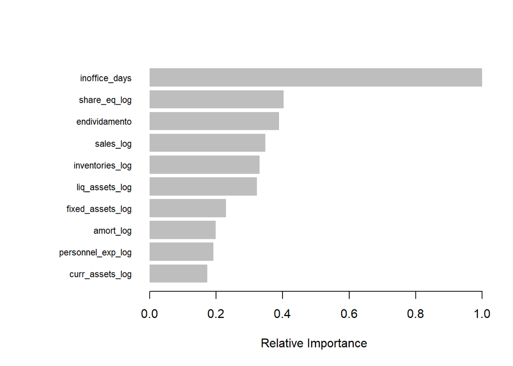

```r
importancia <- xgb.importance(model = xgb_model)

xgb.plot.importance(importancia, rel_to_first = TRUE, xlab = "Relative Importance", top_n = 10)
```

Buscando todos os thresholds possíveis

```r
desempenho %>%
  mutate(classes = factor(classes)) %>%
  group_by(metodo) %>%
  roc_curve(classes, prob, event_level = "second")
```

```
## # A tibble: 3,241 × 4
## # Groups:   metodo [1]
##    metodo   .threshold specificity sensitivity
##    <chr>         <dbl>       <dbl>       <dbl>
##  1 xgboost -Inf           0                  1
##  2 xgboost    0.000599    0                  1
##  3 xgboost    0.000625    0.000361           1
##  4 xgboost    0.000630    0.000721           1
##  5 xgboost    0.000643    0.00108            1
##  6 xgboost    0.000652    0.00144            1
##  7 xgboost    0.000752    0.00180            1
##  8 xgboost    0.000790    0.00216            1
##  9 xgboost    0.000843    0.00252            1
## 10 xgboost    0.000845    0.00288            1
## # ℹ 3,231 more rows
```

Selecionando o melhor threshold e plotando a matriz de confusão final

```r
df_threshold <- desempenho %>%
  mutate(classes = factor(classes)) %>%
  group_by(metodo) %>%
  roc_curve(classes, prob, event_level = "second")

gmeans <- sqrt(df_threshold$sensitivity * df_threshold$specificity)

(ideal_threshold <- df_threshold[which.max(gmeans),]$.threshold)
```

```
## [1] 0.1425329
```

```r
pred_ <- as.factor(ifelse(predict(xgb_model, d_test, type="response")>=ideal_threshold,"1","0"))

caret::confusionMatrix(data=pred_, reference = factor(conj_teste$target), positive='1')
```

```
## Confusion Matrix and Statistics
##
##           Reference
## Prediction    0    1
##          0 2091  106
##          1  682  360
##
##                Accuracy : 0.7567
##                  95% CI : (0.7416, 0.7714)
##     No Information Rate : 0.8561
##     P-Value [Acc > NIR] : 1
##
##                   Kappa : 0.3478
##
##  Mcnemar's Test P-Value : <2e-16
##
##             Sensitivity : 0.7725
##             Specificity : 0.7541
##          Pos Pred Value : 0.3455
##          Neg Pred Value : 0.9518
##              Prevalence : 0.1439
##          Detection Rate : 0.1111
##    Detection Prevalence : 0.3217
##       Balanced Accuracy : 0.7633
##
##        'Positive' Class : 1
##
```